### Assignment1

**This is a R Markdown document for the Peer Assignment1.The explanation for each task are presented before the code chunks.**

#### Setting Global options for Code chunks

```r
   library(knitr)
   opts_chunk$set(echo=TRUE)
```

#### Reading data to R

In this section we load data to R and change type of the **date** column into a proper format.

```r
   raw_data<-read.csv('activity.csv',sep=",",na.strings="NA")
   prcs_data<-transform(raw_data,date=as.Date(as.character(date),format="%Y-%m-%d"))
```

#### The mean total number of steps taken per day

- First we retrieve the data from the processed data and we need to ignore the NA values here.

```r
aggr1<-aggregate(prcs_data[!is.na(prcs_data$steps),c('steps')],by=list(days=prcs_data[!is.na(prcs_data$steps),                          c('date')]),FUN=sum)
```

- Second we use the ggplot2 system to plot the histogram

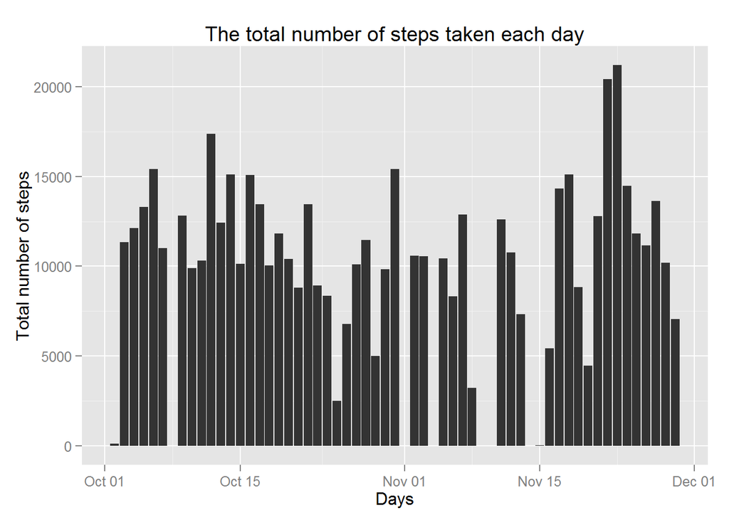

```r
   library(ggplot2)
   p1<-ggplot(aggr1, aes(x =days , y = x))
   p1<-p1+geom_bar(stat = "identity")
   p1<-p1+ggtitle('The total number of steps taken each day')
   update_labels(p1, list(x="Days",y="Total number of steps"))
```

**The mean and median total number of steps taken per day**

```r
  mn1<-mean(aggr1$x)
  md1<-median(aggr1$x)
```

- The mean total number of steps taken per day is **1.0766 × 10<sup>4</sup>**
- The median total number of steps taken per day is **10765**

#### The average daily activity pattern

- First we retrieve the data from the processed data and we need to ignore the NA values

```r
aggr2<-aggregate(prcs_data[!is.na(prcs_data$steps) & !is.na(prcs_data$interval),c('steps')],
                 by=list(intervals=prcs_data[!is.na(prcs_data$steps) & !is.na(prcs_data$interval),
                 c('interval')]),FUN=mean)
```

- Second we plot time series of 5-minute interval

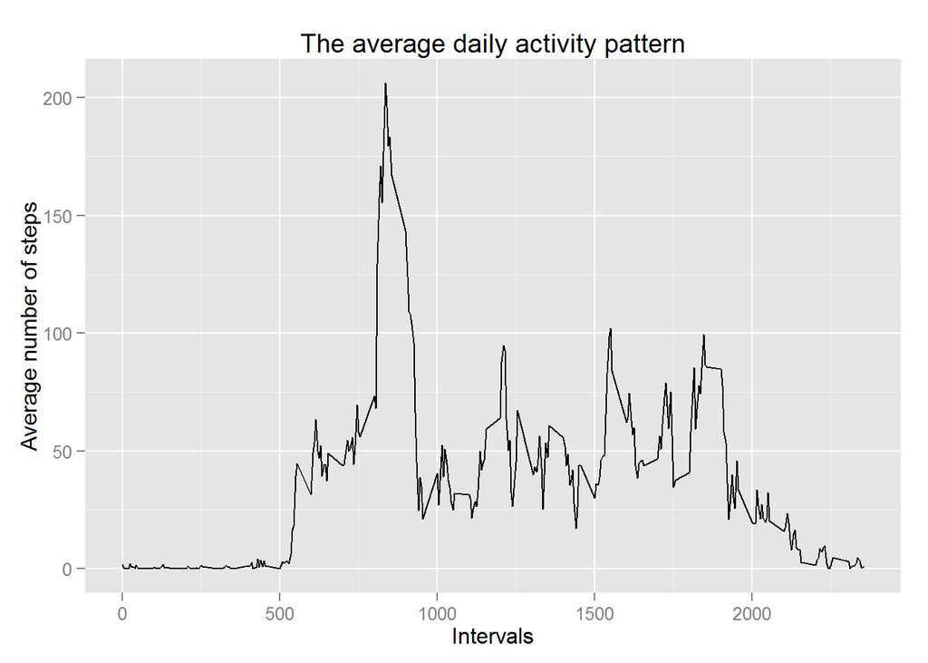

```r
   library(ggplot2)
   p2<-ggplot(aggr2, aes(x =intervals , y = x))
   p2<-p2+geom_line(stat = "identity")
   p2<-p2+ggtitle('The average daily activity pattern')
   update_labels(p2, list(x="Intervals",y="Average number of steps"))
```

**The 5-minute interval with the maximum number of steps**

```r
mx<-aggr2[aggr2$x==max(aggr2$x),c('intervals')]
```

The **835th** interval contains the maximum number of steps on average all the days in data set.

#### Imputing missing values

```r
rows_na<-prcs_data[is.na(prcs_data$steps) | is.na(prcs_data$date) | is.na(prcs_data$interval),  ]
Total<-nrow(rows_na)
```

The total number of rows with NAs is **2304**

- We used the mean for each 5-minute interval to fill NAs and to create prcs_data_no_NA dataset without NAs

```r
prcs_data_no_NA<-prcs_data

for (i in 1: nrow(aggr2)) {

  temp_mean<-aggr2[i,2]
  temp_interval<-aggr2[i,c('intervals')]
  for(j in 1:nrow(prcs_data_no_NA)){

       if(is.na(prcs_data_no_NA[j,c('steps')]) & (prcs_data_no_NA[j,c('interval')]==temp_interval))
       prcs_data_no_NA[j,c('steps')]<-temp_mean
  }
}
```

#### The impact of imputing missing data on the estimates of the total daily number of steps

- First retrieve the proper data from prcs_data_no_NA to plot

```r
   aggr4<-aggregate(prcs_data_no_NA[,c('steps')],
                    by=list(days=prcs_data_no_NA[,c('date')]),FUN=sum)
```

- Second use the ggplot2 system to plot the histogram

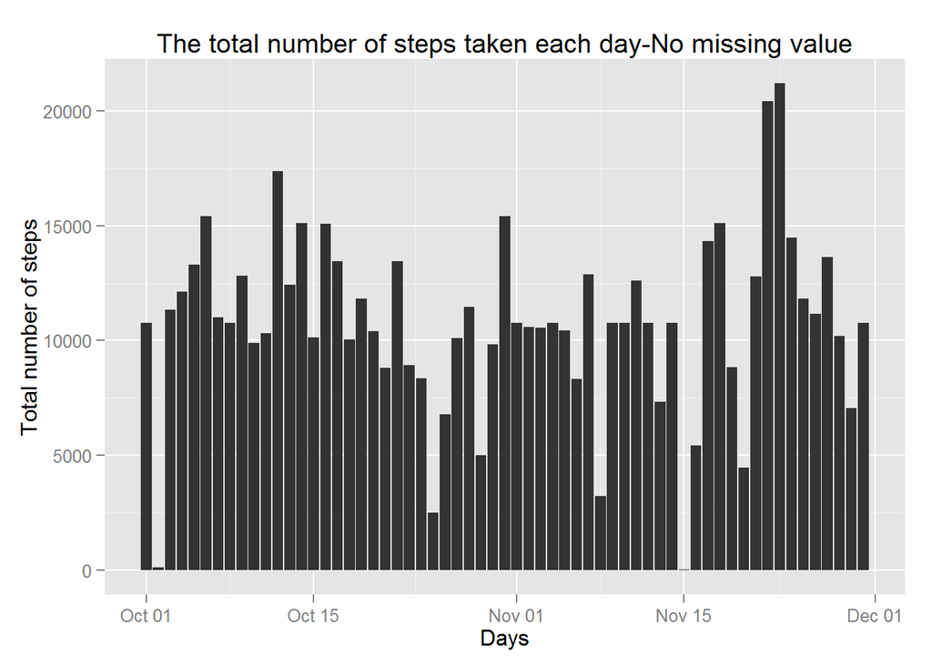

```r
   library(ggplot2)
   p3<-ggplot(aggr4, aes(x =days , y = x))
   p3<-p3+geom_bar(stat = "identity")
   p3<-p3+ggtitle('The total number of steps taken each day-No missing value')
   update_labels(p3, list(x="Days",y="Total number of steps"))
```

**The mean and median total number of steps taken per day**

```r
   mn3<-mean(aggr4$x)
   md2<-median(aggr4$x)
if (mn3<mn1)
{  word1<-'smaller than'
}else {if(mn3>mn1)
  {word1<-'bigger than'

}else
  word1<-'equal with'}

if (md2<md1)
{ word2<-'smaller than'
}else{if (md2>md1)
  {word2<-'bigger than'
}else
  word2<-'equal with'}
```

**The mean total number of steps taken per day is 1.0766 × 10<sup>4</sup> and is equal with the previous mean**  
**The median total number of steps taken per day is 1.0766 × 10<sup>4</sup>and is bigger than the previous median**  
**On the whole no significant change has been seen on the estimates of the total number of steps in comparison with the case that we did not handle the NAs**

#### The differences in activity patterns between weekdays and weekends

- First we create a new factor variable in the dataset with two levels - “weekday” and “weekend”

```r
prcs_data_no_NA$day_Type <-as.factor(ifelse((weekdays(prcs_data_no_NA$date,T) %in% c('Sat','Sun')),'weekend','weekday'))
```

- Second we retrieve the proper data from prcs_data_no_NA to plot

```r
   aggr5<-aggregate(prcs_data_no_NA[,c('steps')],by=list(intervals=prcs_data_no_NA[,c('interval')],
                                                         day_type=prcs_data_no_NA[,c('day_Type')]),FUN=mean)
```

- Third we use the ggplot2 system to plot

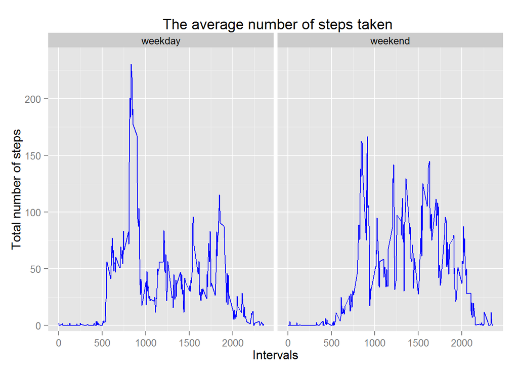

```r
   library(ggplot2)
   p5<-ggplot(aggr5[!is.na(aggr5$x),], aes(x =intervals , y = x))
   p5<-p5+geom_line(colour='blue')+coord_cartesian(ylim = c(-5, 245))
   p5<-p5+facet_grid(.~ day_type ,scales='free',space='free')
   p5<-p5+ggtitle(' The average number of steps taken')
   update_labels(p5, list(x="Intervals",y="Total number of steps"))
```